# AFFIP session data

Nico Bast

2026-01-16

# 1 Forschungsziel

Cluster der Therapieziele identifizieren - Verlauf der Probanden

1. Bildet sich der theoretische Ansatz des A-FFIP-Manuals mit den einzelne Förderbereichen sowie den Übungen von leicht bis Experte auch in der praktischen Arbeit mit den einzelnen Kindern ab? D.h. lernen die Kinder wie angenommen durch die Therapie aufeinander aufbauend über die entsprechenden Übungen?

2. Mit welchen Förderbereichen wird begonnen? Gibt es hier Zusammenhänge mit Alter, nonverbaler und verbaler Entwicklung sowie autistischer Kernsymptomatik und anderen Verhaltensweisen?

–> siehe 4.4.: es gibt 5 Cluster von Zielen mit denen begonnen wird. Mit drei großen Clustern: Blickkontakt + Imitation (n=29), Blickkontakt + Aufmerksamkeit (n=13) und expressive Sprache + Blickkontakt (n = 10). Diese sind unabhängig von Kovariaten –> siehe 4.3.2.: die Anzahl der Sitzungen bis mit der Arbeit an Therapiezielen begonnen werden beeinflusst durch höhere Alter, höherer IQ, und Beginn der Sitzungen vor dem Corona Lockdown

3. Wie bauen die Förderbereiche aufeinander auf, von welchem Förderbereich wird zum anderen gewechselt? Gibt es hier spezifische Muster, sind diese vergleichbar zwischen den Kindern oder zeigen verschiedene Gruppen von Kindern in sich ähnliche aber zwischen den Gruppen unterschiedliche Muster? Gibt es hier Zusammenhänge mit Alter, nonverbaler und verbaler Entwicklung sowie autistischer Kernsymptomatik und anderen Verhaltensweisen?

–> Diskussionspunkt: bisher liegt Fokus auf Ketten von Zielen, diese Untersuchung würde Fokus auf Transitionen von Zielen erweitern

# 2 spezifische Analysen

##January 2026

```
1. Welche Faktoren beeinflussen Beginn der Arbeit an Zielen?
    - Einfluss Alter, Geschlecht, Parent education, Migrationsstatus, Corona, IQ, SES
    - -> age, IQ, and lockdown haben einen Einfluss
2. Cluster der Therpapieziele zum Einstieg
    - Eher 3 große Cluster Modellieren
    - -> 5 Clusters are more useful to get a language cluster
    - Einfluss Alter, Geschlecht, Parent education, Migrationsstatus, Corona, IQ, SES - nicht-parametrische Testung
    - --> keinen Einfluss auf Start Cluster
3. Session Verlauf - anhand der Kettenmodellierung
    a. Ketten auf Ebene der Ziele
    b. Ketten auf Ebene der Entwicklungsbereiche  (developmental area)
    c. Ketten auf Ebene der Einzelziele (Expertlevel)
```

##Modellierung

```
- Ketten von zielen herausarbeiten
    ○ Mindestens zweimal bis dreimal bearbeitete Ziele berücksichtigen
- Outcome Ziel:
    ○ Zielebene gemeistert (2) und
    ○ Ausmaß Hilfestellung (2)
    ○ Zielanzahl
    ○ Wie lange Zielkette
- Pro Ziel und Kind geschaut, wie Lange an Ziel gearbeitet und mastery
- Anhand der Ketten und Qualität der ketten Clustern
```

## 2.1 TODO

- model transitions of aims between chains
- discuss: exclude low occurances aims (focus on prevalent aims)
- discuss: exclude chains of length < 2

# 3 data overview and preparation

- loads the data
- derives relevant data points
- describes the data

```r
#session data --> multiple rows per participant per session
project_folder<-"C:/Users/nico/Nextcloud/data_AFFIP/rct_data"
session_path<-paste0(project_folder,'/export_session_20230728.csv')
df_session<-read.csv(session_path)

#therapy data --> one row per participant per session
therapy_path<-paste0(project_folder,'/export_therapy_20230728.csv') #therapy session info - per session
df_therapy<-read.csv(therapy_path)

#gender and age in months
screen_path<-paste0(project_folder,'/export_screen_20230728.csv')
df_screen<-read.csv(screen_path) #master merge file
df_screen<-df_screen[,names(df_screen) %in% c('centno','scrnno','gender','agedemo','age_y','age_m')]

#IQ
wppsi_path<-paste0(project_folder,'/export_wppsi_20240916.csv')
df_wppsi<-read.csv(wppsi_path)
bayley_path<-paste0(project_folder,'/export_bayley_20240916.csv')
df_bayley<-read.csv(bayley_path)

#migration info
rct_path<-paste0(project_folder,'/export_rct_20230728.csv')
df_rct<-read.csv(rct_path)

#socioeconomic status
ses_path<-paste0(project_folder,'/export_ses_20230728.csv') #socioeconomic status
df_ses<-read.csv(ses_path)
```

```r
#based on A-FFIP data preprocessing script


#select relevant data
df_wppsi <- df_wppsi[,names(df_wppsi) %in% c('centno', 'scrnno', 't', 'wppsi_ver','wppsidate',
                                             'vtiq', 'htiq', 'vgiq', 'asiq', 'gsiq', 'ta_wppsi_mean',
                                             'develop_age_w','verbal_iqdq_w','nonverbal_iqdq_w',
                                             'wppsi_ver','wppsidate_d','wppsidate_m','wppsidate_y')]

df_bayley<-df_bayley[,names(df_bayley) %in% c('centno','scrnno','t','baydate','develop_age',
                                              'verbal_iqdq','nonverbal_iqdq',
                                              'cognea','rezea','exprea')]

#merge data
df_iq<-merge(df_wppsi,df_bayley,by=c('centno','scrnno','t'),all.x=T,all.y=T)

#merge chronological age
df_age<-df_screen[,names(df_screen) %in% c('centno','scrnno','agedemo')]
names(df_age)[3]<-'chronage'
df_iq<-merge(df_iq,df_age,by=c('centno','scrnno'))

#Testalter (historisch)
#IQ estimate as test age /developmental age * 100
#df_iq$test_age<-with(df_iq,ifelse(is.na(ta_wppsi_mean),develop_age,ta_wppsi_mean))
df_iq$test_age<-with(df_iq,ifelse(is.na(develop_age_w),develop_age,develop_age_w))

#langugae development - not aggregated
df_iq$lang_dev<-df_iq$develop_age
df_iq$lang_dev_w<-df_iq$chronage / 100 * df_iq$asiq

#non-verbal IQ
nonverbal_iq<-df_iq$cognea / df_iq$chronage * 100
nonverbal_iq_w<-df_iq$htiq
df_iq$nonverbal_iq<-ifelse(is.na(nonverbal_iq),nonverbal_iq_w,nonverbal_iq)

#verbal IQ
verbal_iq<-((df_iq$exprea + df_iq$rezea) / 2) / df_iq$chronage * 100
verbal_iq_w<-df_iq$vtiq
df_iq$verbal_iq<-ifelse(is.na(verbal_iq),verbal_iq_w,verbal_iq)

#full IQ
full_iq<-((df_iq$exprea + df_iq$rezea + df_iq$cognea) / 3) / df_iq$chronage * 100
full_iq_w<-df_iq$gsiq
df_iq$full_iq<-ifelse(is.na(full_iq),full_iq_w,full_iq)

#full IQ - if nonverbal was measured with WPPSI_III and verbal with Bayley-III
# --> recovers 12 full scale IQs (!)
boolean_mixed<-!is.na(verbal_iq) & !is.na(nonverbal_iq_w)
df_iq$full_iq[boolean_mixed]<-
  ((df_iq$exprea[boolean_mixed]/df_iq$chronage[boolean_mixed] * 100) +
  (df_iq$rezea[boolean_mixed]/df_iq$chronage[boolean_mixed] * 100) +
  df_iq$htiq[boolean_mixed]) / 3

#developmental age
develop_age<-(df_iq$exprea + df_iq$rezea + df_iq$cognea) / 3
develop_age_w<-df_iq$chronage / 100 * df_iq$gsiq
df_iq$develop_age<-develop_age
df_iq$develop_age_w<-develop_age_w
```

## 3.1 variable description

Data should be limited to: - Bezugsperson anwesend = 0 (ohne Bezugsperson) - Schwerpunkt = 2 (kindzentriert) - Setting = 1 (Einzeltherapie) - Diagnostiktermin = 0 (kein Diagnostiktermin)

```r
#Bezugsperson anwesen
table(df_therapy$thcg) %>%
  kbl(caption = "thcg: Bezugsperson anwesend (0 = no, 1=yes)") %>%
  kable_classic(full_width = T, html_font = "Cambria")
```

thcg: Bezugsperson anwesend (0 = no, 1=yes)

| Var1 | Freq |
| --- | --- |
| 0 | 3034 |
| 1 | 1556 |

```r
# --> inclusion only with 0

#Schwerpunkt
table(df_therapy$focus) %>%
  kbl(caption = "focus: Bezugsperson anwesend (1 = Elternarbeit, 2 = Kind, 3 = Austausch / Umfeld)") %>%
  kable_classic(full_width = T, html_font = "Cambria")
```

focus: Bezugsperson anwesend (1 = Elternarbeit, 2 = Kind, 3 = Austausch / Umfeld)

| Var1 | Freq |
| --- | --- |
| 1 | 277 |
| 2 | 4207 |
| 3 | 106 |

```r
# 1 = Elternarbeit
# 2 = Kind
# 3 = Austausch / Umfeld

#Setting
table(df_therapy$set) %>%
  kbl(caption = "set: Setting (1 = Einzel, 2 = Gruppe, 3 = Gespräch, 4 = Hospitation Kindergarten") %>%
  kable_classic(full_width = T, html_font = "Cambria")
```

set: Setting (1 = Einzel, 2 = Gruppe, 3 = Gespräch, 4 = Hospitation Kindergarten

| Var1 | Freq |
| --- | --- |
| 1 | 4118 |
| 2 | 77 |
| 3 | 351 |
| 4 | 44 |

```r
# 1 = Einzel
# 2 = Gruppe
# 3 = Gespräch
# 4 = Hospitation Kindergarten


table(df_therapy$thcg,df_therapy$focus,df_therapy$set) %>%
  kbl(caption = "Bezugsperson x Schwerpunkt x Setting",
      col.names = c('Bezugsperson','Schwerpunkt','Setting','N')) %>%
  kable_classic(full_width = T, html_font = "Cambria")
```

Bezugsperson x Schwerpunkt x Setting

| Bezugsperson | Schwerpunkt | Setting | N |
| --- | --- | --- | --- |
| 0 | 1 | 1 | 0 |
| 1 | 1 | 1 | 5 |
| 0 | 2 | 1 | 2919 |
| 1 | 2 | 1 | 1194 |
| 0 | 3 | 1 | 0 |
| 1 | 3 | 1 | 0 |
| 0 | 1 | 2 | 1 |
| 1 | 1 | 2 | 0 |
| 0 | 2 | 2 | 70 |
| 1 | 2 | 2 | 6 |
| 0 | 3 | 2 | 0 |
| 1 | 3 | 2 | 0 |
| 0 | 1 | 3 | 1 |
| 1 | 1 | 3 | 270 |
| 0 | 2 | 3 | 3 |
| 1 | 2 | 3 | 15 |
| 0 | 3 | 3 | 21 |
| 1 | 3 | 3 | 41 |
| 0 | 1 | 4 | 0 |
| 1 | 1 | 4 | 0 |
| 0 | 2 | 4 | 0 |
| 1 | 2 | 4 | 0 |
| 0 | 3 | 4 | 19 |
| 1 | 3 | 4 | 25 |

```r
#Diagnostiktermin
table(df_therapy$diag) %>%
  kbl(caption = "diag: Diagnostiktermin (0 = nein)") %>%
  kable_classic(full_width = T, html_font = "Cambria")
```

diag: Diagnostiktermin (0 = nein)

| Var1 | Freq |
| --- | --- |
| 0 | 4490 |
| 1 | 1 |
| 3 | 64 |
| 4 | 62 |
| 5 | 62 |
| 6 | 52 |

```r
# 0 = kein Diagnostiktermin
```

### 3.1.1 number of aims per session

- number of aims within the session
- Es gibt keine Zielreihenfolge (Zielnummer definiert nicht die Priorität)

```r
#Ziel Nummer
table(df_session$aim)  %>%
  kbl(caption = "aim: Mindestanzhal von Zielen pro Sitzung (kummulativ)") %>%
  kable_classic(full_width = T, html_font = "Cambria")
```

aim: Mindestanzhal von Zielen pro Sitzung (kummulativ)

| Var1 | Freq |
| --- | --- |
| 0 | 1 |
| 1 | 4161 |
| 2 | 4154 |
| 3 | 4117 |
| 4 | 3992 |
| 5 | 3823 |
| 6 | 3586 |
| 7 | 2618 |
| 8 | 1112 |
| 9 | 15 |

```r
##-->  aim number within the session (3 = third of three aims)
##
```

### 3.1.2 additional variables

- only consider aims that were actually trained (practex)
- help (0) and achieve (2) could define an outcome

```r
#Übung durchgeführt
table(df_session$practex) %>%
  kbl(caption = "practex: Übung durchgeführt") %>%
  kable_classic(full_width = T, html_font = "Cambria")
```

practex: Übung durchgeführt

| Var1 | Freq |
| --- | --- |
| 0 | 3809 |
| 1 | 23770 |

```r
#Ausmaß Hilfestellung: 0 = ohne Hilfe, 1 = mit Hilfestellung, 2 = selbstständig
table(df_session$help) %>%
  kbl(caption = "help: Ausmaß Hilfestellung (0 = Hilfe notwendig, 1 = mit Hilfestellung, 2 = selbstständig)") %>%
  kable_classic(full_width = T, html_font = "Cambria")
```

help: Ausmaß Hilfestellung (0 = Hilfe notwendig, 1 = mit Hilfestellung, 2 = selbstständig)

| Var1 | Freq |
| --- | --- |
| 0 | 2643 |
| 1 | 13932 |
| 2 | 5535 |
| 8 | 1 |

```r
#Zielebene gemeistert - 0= nein, 1 = teilweise, 2 = vollständig
table(df_session$achieve) %>%
  kbl(caption = "achieve: Zielebene gemeistert (0 = nein, 1 = teilweise, 2 = vollständig)") %>%
  kable_classic(full_width = T, html_font = "Cambria")
```

achieve: Zielebene gemeistert (0 = nein, 1 = teilweise, 2 = vollständig)

| Var1 | Freq |
| --- | --- |
| 0 | 2477 |
| 1 | 14363 |
| 2 | 5270 |
| 8 | 1 |

```r
#if Übung durchgeführt, then: Übung variiert
table(df_session$practvar)
```

```
##
##     0     1     2
##  7878 14232     2
```

```r
## --> currentlky not relevant

#herausfordernde Verhaltensweisen gezeigt
table(df_session$behave)
```

```
##
##     0     1     2     7
## 25842  1706     4    27
```

## 3.2 merge data

- merges df_session (session data, p.12ff) and df_therapy (therapy data, p1-12)
- df_session: row per aim per session (n=27579)
- df_therapy: row per session (n=4731)
- adds an ID variable based on centno + scrnno

```r
df_trial<-merge(df_session, df_therapy,
            by.x = c("centno", "scrnno", "sessno"),
            by.y= c("centno", "scrnno", "thsessno"))

names(df_trial)
```

```
##  [1] "centno"        "scrnno"        "sessno"        "bdate_m.x"
##  [5] "bdate_y.x"     "sdate_d"       "sdate_m"       "sdate_y"
##  [9] "therapeut"     "therapeutno"   "cotherapeut"   "cotherapeutno"
## [13] "sesscg"        "sesscg1"       "sesscg2"       "sesscg3"
## [17] "sesscg4"       "sesscg5"       "sesscg6"       "sesscg7"
## [21] "sesscg8"       "sessothcg"     "aim"           "aimno"
## [25] "practex"       "practvar"      "help"          "achieve"
## [29] "behave"        "sdate_"        "bdate_m.y"     "bdate_y.y"
## [33] "week"          "thdate_d"      "thdate_m"      "thdate_y"
## [37] "thcg"          "thcg1"         "thcg2"         "thcg3"
## [41] "thcg4"         "focus"         "set"           "diag"
## [45] "patcsdoc"      "sessdoc"       "thidate_d"     "thidate_m"
## [49] "thidate_y"     "thinvest"      "thisign"       "thpage"
## [53] "thdate_"       "thidate"
```

```r
#create IDs variable
df_trial$id<-paste(df_trial$centno,df_trial$scrnno,sep='.')
```

- adds demographic data

```r
#adds agedemo, gender
df_trial<-merge(df_trial,df_screen, by = c("centno", "scrnno"))

#adds iq
df_iq<-df_iq[df_iq$t==1,names(df_iq)!='t'] #at earliest timepoint
df_trial<-merge(df_trial,df_iq, by = c("centno", "scrnno"))

#migration info
df_rct<-df_rct[,!(names(df_rct) %in% c('bdate_m','bdate_y'))]
df_rct<-df_rct[,names(df_rct)!='t']
df_trial<-merge(df_trial,df_rct, by = c("centno", "scrnno"), all.x = T)

#parental education and SES
selected_vars<-c("centno","scrnno","ses_edumean_t1","maxschool_t1")
df_ses<-df_ses[,names(df_ses) %in% selected_vars]
df_trial<-merge(df_trial,df_ses, by = c("centno", "scrnno"))
```

## 3.3 sample definition

- retain only data for subsequent analysis that is
  - without caregiver (df_trial$thcg==0)
  - focused on child (df_trial$focus==2)
  - Einzeltherapie (df_trial$set==1)
  - no diagnostic assessment (df_trial$diag==0)
  - actually trained aims (df_trail$practex==1)

```r
total_aims<-nrow(df_trial)

df_trial<-df_trial[df_trial$thcg==0 & df_trial$focus==2 & df_trial$set==1 & df_trial$diag==0 & df_trial$practex==1,]

print(paste0('retained data percentage:',round(nrow(df_trial)/total_aims,2)))
```

```
## [1] "retained data percentage:0.61"
```

## 3.4 pandemic break

- first shutdown in Germany: 22/03/2020 - 04/05/2020
- calculate a corona state based on lockdown onset (after_lockdown=T == session after 22/03/20)

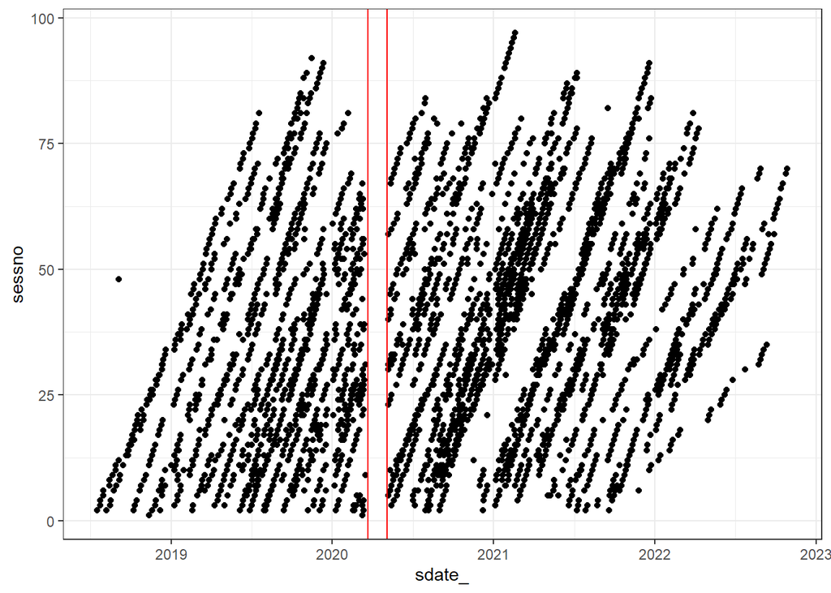

```r
  lockdown_start_germany<-as.Date("22/03/20", format = "%d/%m/%y")
  lockdown_end_germany<-as.Date("04/05/20", format = "%d/%m/%y")


  #across all
  df_trial$sdate_<-as.Date(df_trial$sdate_, format = "%d/%m/%y")
  ggplot(df_trial,aes(sdate_,sessno))+geom_point()+
    geom_vline(xintercept=lockdown_start_germany,color='red')+
    geom_vline(xintercept=lockdown_end_germany,color='red')
```

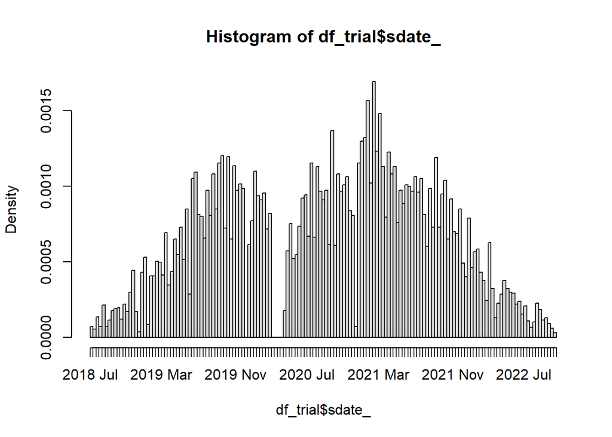

```r
  hist(df_trial$sdate_,150)
```

```r
  df_trial$after_lockdown<-ifelse(df_trial$sdate_>lockdown_start_germany,T,F)
  table(df_trial$after_lockdown)
```

```
##
## FALSE  TRUE
##  5870 10856
```

## 3.5 participants & sessions

- shows participants ids (centno.scrnno)
- sessions by participant
- define an ID variable for df_trial

```r
#participants
print('number of participants:')
```

```
## [1] "number of participants:"
```

```r
length(table(interaction(df_trial$centno,df_trial$scrnno,drop=T)))
```

```
## [1] 63
```

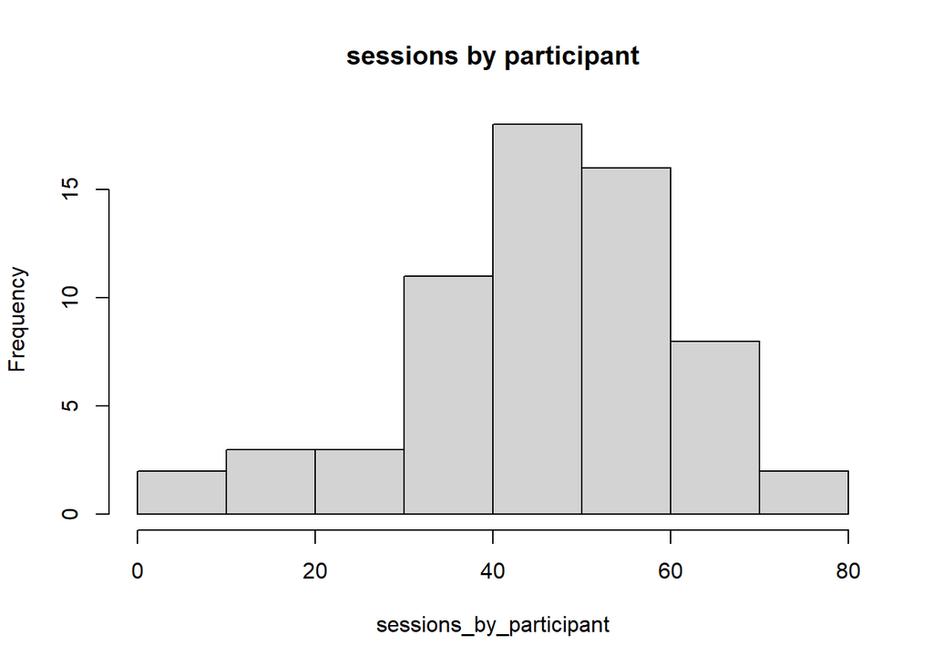

```r
#session by participant
sessions_by_participant<-as.numeric(
  by(df_trial$sessno,interaction(df_trial$centno,df_trial$scrnno,drop=T),function(x){length(unique(x))}))
hist(sessions_by_participant,main = 'sessions by participant')
```

```r
print('participant IDs')
```

```
## [1] "participant IDs"
```

```r
participant_IDs<-names(table(interaction(df_trial$centno,df_trial$scrnno,drop=T)))

df_ids<-data.frame(participant_IDs,sessions_by_participant)

df_ids %>%
  kbl(caption = "Sessions by participant") %>%
  kable_classic(full_width = T, html_font = "Cambria")
```

Sessions by participant

| participant_IDs | sessions_by_participant |
| --- | --- |
| 4.1 | 38 |
| 2.2 | 55 |
| 3.2 | 17 |
| 4.2 | 48 |
| 1.3 | 60 |
| 2.4 | 28 |
| 3.4 | 31 |
| 1.5 | 66 |
| 4.9 | 39 |
| 4.10 | 11 |
| 1.11 | 52 |
| 2.11 | 56 |
| 4.15 | 54 |
| 2.16 | 51 |
| 1.17 | 46 |
| 4.17 | 67 |
| 2.19 | 37 |
| 4.19 | 46 |
| 2.21 | 63 |
| 4.23 | 6 |
| 4.25 | 32 |
| 2.29 | 45 |
| 1.31 | 41 |
| 2.31 | 61 |
| 3.31 | 46 |
| 1.32 | 1 |
| 2.33 | 60 |
| 1.34 | 64 |
| 2.35 | 50 |
| 1.37 | 52 |
| 2.39 | 53 |
| 1.42 | 42 |
| 2.46 | 41 |
| 1.48 | 38 |
| 1.50 | 63 |
| 1.51 | 74 |
| 2.51 | 46 |
| 2.52 | 55 |
| 1.54 | 31 |
| 2.54 | 14 |
| 1.55 | 29 |
| 3.55 | 49 |
| 1.60 | 58 |
| 1.62 | 57 |
| 1.70 | 75 |
| 1.74 | 56 |
| 1.76 | 51 |
| 1.78 | 39 |
| 1.81 | 65 |
| 1.82 | 60 |
| 1.83 | 44 |
| 1.87 | 49 |
| 1.93 | 61 |
| 1.94 | 43 |
| 1.97 | 48 |
| 3.98 | 43 |
| 1.99 | 39 |
| 1.101 | 43 |
| 1.105 | 29 |
| 3.106 | 48 |
| 1.113 | 55 |
| 1.116 | 32 |
| 1.117 | 38 |

## 3.6 exclude participants

- exclude participant with only one session (id = 1.32)

```r
df_trial<-df_trial[!df_trial$id=='1.32',]
```

# 4 therapy aims

- can be more than one per session
- encoded by “aimno” variable (e.g. 10.6.2.1)
  - first or two numbers define devleopmental area (e.g. 9, 10.2-10.6)
  - first three numbers define specific aim (e.g. 10.6.2)
  - last number defines expert level (1,2,3)

## 4.1 developmental area

- Entwicklungsbereiche (9.2 - 10.6)

```r
## Ziele overall
#table(df_trial$aimno)

#create data
dev_area<-substr(df_trial$aimno,1,8)
dev_area<-ifelse(nchar(dev_area)==5,substr(dev_area,1,1),dev_area)
dev_area<-ifelse(nchar(dev_area)==8,substr(dev_area,1,4),dev_area)
dev_area<-ifelse(grepl("A",dev_area),'A',dev_area)
dev_area<-ifelse(grepl("B",dev_area),'B',dev_area)
dev_area<-ifelse(grepl("-8",dev_area),NA,dev_area)

dev_area_char<-dev_area
dev_area<-as.factor(dev_area)
levels(dev_area)<-c('communication & speech (10.2)','interaction & play (10.3)','emotion (10.4)','cognitive ability (10.5)','daily living skills (10.6)','basic abilities (9)','introduction (A)','reduction of unwanted behaviors (B)')

df_trial$dev_area<-dev_area
df_trial$dev_area_char<-dev_area_char

#visualize data
dev_area_table<-data.frame(sort(table(df_trial$dev_area),decreasing = TRUE))
dev_area_table_char<-data.frame(sort(table(df_trial$dev_area_char),decreasing = TRUE))
dev_area_table$dev_area_char<-dev_area_table_char$Var1
dev_area_table<-dev_area_table[,c(1,3,2)]

dev_area_table %>%
  kbl(caption = "developmental areas across sessions") %>%
  kable_classic(full_width = T, html_font = "Cambria")
```

developmental areas across sessions

| Var1 | dev_area_char | Freq |
| --- | --- | --- |
| communication & speech (10.2) | 10.2 | 5443 |
| basic abilities (9) | 9 | 5178 |
| interaction & play (10.3) | 10.3 | 2538 |
| daily living skills (10.6) | 10.6 | 1163 |
| introduction (A) | A | 1090 |
| cognitive ability (10.5) | 10.5 | 844 |
| emotion (10.4) | 10.4 | 428 |
| reduction of unwanted behaviors (B) | B | 39 |

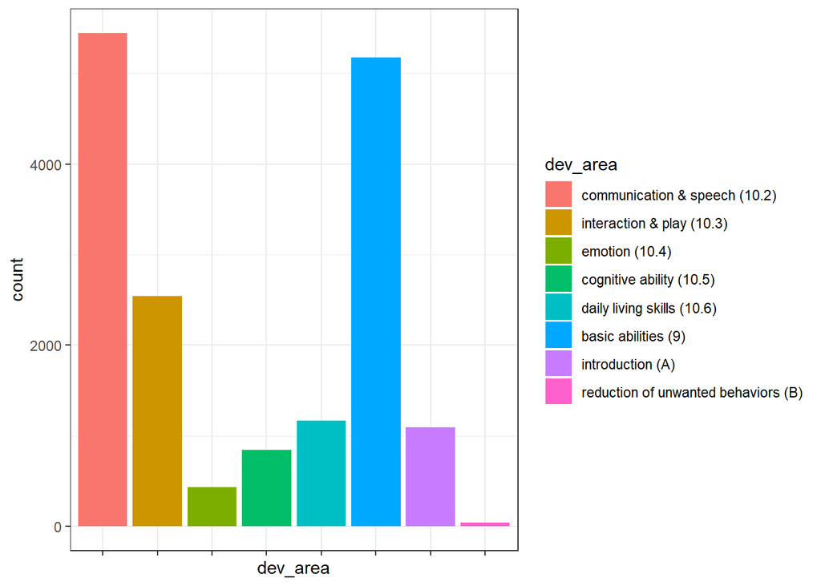

```r
ggplot(df_trial,aes(x=dev_area,fill=dev_area))+geom_bar()+theme(axis.text.x=element_blank())
```

## 4.2 aims across sessions

- an welchen zielen wurde gearbeitet?

```r
## Ziele overall
#table(df_trial$aimno)

aims<-substr(df_trial$aimno,1,8)
aims<-ifelse(nchar(aims)==8,substr(aims,1,6),aims)
aims<-ifelse(nchar(aims)==5,substr(aims,1,3),aims)
aims<-ifelse(grepl("-8",aims),NA,aims)

aims_rank<-aims
aims_rank<-ifelse(grepl('10',aims_rank),substr(aims_rank,6,6),aims_rank)
aims_rank<-ifelse(grepl('9',aims_rank),substr(aims_rank,3,3),aims_rank)
aims_rank<-ifelse(grepl('A',aims_rank),NA,aims_rank)
aims_rank<-ifelse(grepl('B',aims_rank),NA,aims_rank)
df_trial$aims_rank<-aims_rank

aims_char<-aims
aims<-as.factor(aims)
levels(aims)<-c('eye contact','passive vocabulary','gesture','expressive language (supported)',
                'expressive language extended','questions & answers','making contact',

                'shared attention','exchange','sharing','non-interactive play','simple shared play',
                'rule-based play','symbolic play','role play',

                'emotion recognition','emotion expression','emotion regulation',

                'classification','characteristics/opposites','memory',
                'drawing','quantitative understanding','theory of mind',
                'common knowledge',

                'daily routines','toilet training',
                'problem solving','awareness of danger','spatial awareness','temporal orientation',

                'attention control','gaze following',
                'imitation','representation','action planing','self awareness',

                'testing reinforcement','building therapeutic alliance','situational control','separation from caregiver',

                'aggression','stereotypic behavior','alternatives','anxiety','avoidance'

                )

df_trial$aims<-aims
df_trial$aims_char<-aims_char

aims_table<-data.frame(sort(table(df_trial$aims),decreasing = TRUE))
aims_table_char<-data.frame(sort(table(df_trial$aims_char),decreasing = TRUE))
aims_table$aims_char<-aims_table_char$Var1
aims_table<-aims_table[,c(1,3,2)]

  aims_table %>%
  kbl(caption = "occurance of aims across sessions") %>%
  kable_classic(full_width = F, html_font = "Cambria")
```

occurance of aims across sessions

| Var1 | aims_char | Freq |
| --- | --- | --- |
| eye contact | 10.2.1 | 2172 |
| expressive language extended | 10.2.5 | 1322 |
| imitation | 9.4 | 1275 |
| attention control | 9.2 | 1094 |
| action planing | 9.6 | 1018 |
| gaze following | 9.3 | 889 |
| passive vocabulary | 10.2.2 | 885 |
| problem solving | 10.6.3 | 731 |
| expressive language (supported) | 10.2.4 | 645 |
| self awareness | 9.7 | 593 |
| shared attention | 10.3.1 | 577 |
| simple shared play | 10.3.5 | 499 |
| rule-based play | 10.3.6 | 488 |
| situational control | A3 | 471 |
| classification | 10.5.1 | 402 |
| representation | 9.5 | 309 |
| exchange | 10.3.2 | 306 |
| emotion recognition | 10.4.1 | 278 |
| non-interactive play | 10.3.4 | 255 |
| building therapeutic alliance | A2 | 223 |
| testing reinforcement | A1 | 212 |
| temporal orientation | 10.6.6 | 208 |
| questions & answers | 10.2.6 | 186 |
| separation from caregiver | A4 | 184 |
| symbolic play | 10.3.7 | 170 |
| sharing | 10.3.3 | 155 |
| making contact | 10.2.7 | 135 |
| quantitative understanding | 10.5.5 | 133 |
| daily routines | 10.6.1 | 119 |
| drawing | 10.5.4 | 101 |
| gesture | 10.2.3 | 98 |
| emotion regulation | 10.4.3 | 95 |
| theory of mind | 10.5.6 | 94 |
| role play | 10.3.8 | 88 |
| characteristics/opposites | 10.5.2 | 77 |
| awareness of danger | 10.6.4 | 72 |
| emotion expression | 10.4.2 | 55 |
| common knowledge | 10.5.7 | 28 |
| toilet training | 10.6.2 | 22 |
| anxiety | B6 | 13 |
| spatial awareness | 10.6.5 | 11 |
| alternatives | B5 | 11 |
| avoidance | B8 | 10 |
| memory | 10.5.3 | 9 |
| aggression | B1 | 4 |
| stereotypic behavior | B3 | 1 |

```r
aims_table_byrank<-as.matrix(table(df_trial$dev_area,df_trial$aims_rank))

  aims_table_byrank %>%
  kbl(caption = "aim ranks by developmental area across sessions") %>%
  kable_classic(full_width = F, html_font = "Cambria")
```

aim ranks by developmental area across sessions

|  | 1 | 2 | 3 | 4 | 5 | 6 | 7 | 8 |
| --- | --- | --- | --- | --- | --- | --- | --- | --- |
| communication & speech (10.2) | 2172 | 885 | 98 | 645 | 1322 | 186 | 135 | 0 |
| interaction & play (10.3) | 577 | 306 | 155 | 255 | 499 | 488 | 170 | 88 |
| emotion (10.4) | 278 | 55 | 95 | 0 | 0 | 0 | 0 | 0 |
| cognitive ability (10.5) | 402 | 77 | 9 | 101 | 133 | 94 | 28 | 0 |
| daily living skills (10.6) | 119 | 22 | 731 | 72 | 11 | 208 | 0 | 0 |
| basic abilities (9) | 0 | 1094 | 889 | 1275 | 309 | 1018 | 593 | 0 |
| introduction (A) | 0 | 0 | 0 | 0 | 0 | 0 | 0 | 0 |
| reduction of unwanted behaviors (B) | 0 | 0 | 0 | 0 | 0 | 0 | 0 | 0 |

## 4.3 first aims

- remove introduction sessions

```r
#create data
df_firstaims<-df_trial[df_trial$dev_area!='introduction (A)',]
df_firstaims<-split(df_firstaims,df_firstaims$id)
df_firstaims<-lapply(df_firstaims,function(x){
  earliest_session<-min(x$sessno)
  x<-x[x$sessno==earliest_session,]
  return(x)
})
df_firstaims<-rbindlist(df_firstaims)
```

### 4.3.1 sessions till first aims

- Berechnung der Anzahl der Therapiesitzung und Tage, die Kind gebraucht hat, bis an Therapiezielen überhaupt gearbeitet werden kann (Kriterium: Anzahl der „A“-Sitzungen zu Beginn der Therapie“ sowie die Zeitspanne dieser Sitzungen).
- is limited to sessions without caregiver, focused on child, in a single-therapy setting

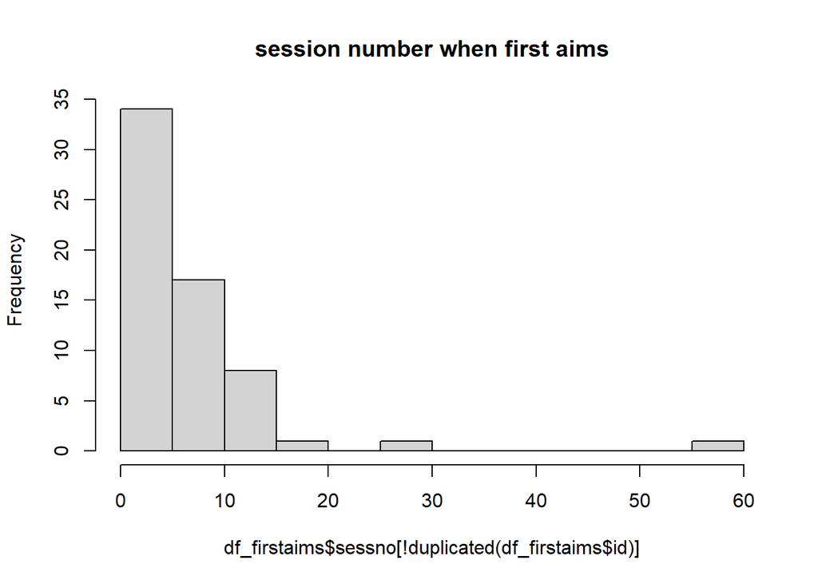

```r
#session number after introduction
hist(df_firstaims$sessno[!duplicated(df_firstaims$id)],
     main = 'session number when first aims',20)
```

```r
table(df_firstaims$sessno[!duplicated(df_firstaims$id)]) %>%
  kbl(caption = "Session number after introduction (after 'A')") %>%
  kable_classic(full_width = T, html_font = "Cambria")
```

Session number after introduction (after ‘A’)

| Var1 | Freq |
| --- | --- |
| 2 | 11 |
| 3 | 8 |
| 4 | 8 |
| 5 | 7 |
| 6 | 3 |
| 7 | 6 |
| 8 | 1 |
| 9 | 4 |
| 10 | 3 |
| 11 | 1 |
| 12 | 5 |
| 13 | 1 |
| 14 | 1 |
| 19 | 1 |
| 28 | 1 |
| 60 | 1 |

#### 4.3.1.1 outlier investigation

- id 2.4 has 60 sessions till first aims
- caregiver was present during first 60 sessions - how to deal with it?

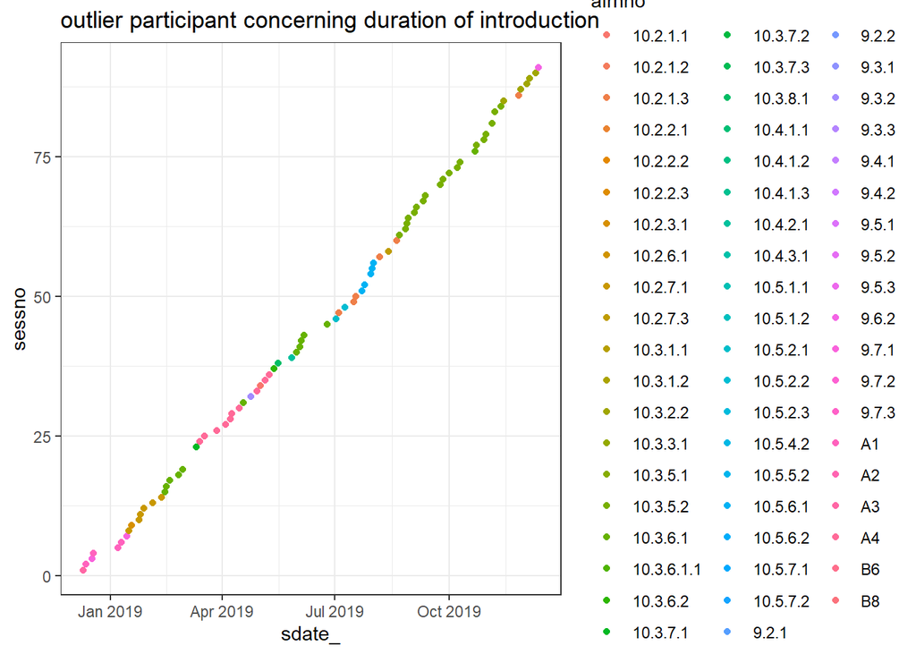

```r
outlier_sessions<-df_session[df_session$centno=='2' & df_session$scrnno=='4',]
outlier_sessions$sdate_<-as.Date(outlier_sessions$sdate_, format = "%d/%m/%y")
ggplot(outlier_sessions,aes(sdate_,sessno,color=aimno))+geom_point()+labs(title= 'outlier participant concerning duration of introduction')
```

```r
outlier_sessions<-outlier_sessions[order(outlier_sessions$sessno),]

outlier_sessions2<-df_therapy[df_therapy$centno=='2' & df_therapy$scrnno=='4',]
table(outlier_sessions2$thcg)
```

```
##
##  0  1
## 31 61
```

### 4.3.2 moderating factors

–> consider those as covariates in testing?

```r
#select only one row per participant
df_firstaims_uniqueID<-df_firstaims[!duplicated(df_firstaims$id),]

#nonparametric testing - categorical variables
print('gender:')
```

```
## [1] "gender:"
```

```r
with(df_firstaims_uniqueID,kruskal.test(sessno ~ as.factor(gender)))
```

```
##
##  Kruskal-Wallis rank sum test
##
## data:  sessno by as.factor(gender)
## Kruskal-Wallis chi-squared = 3.8215, df = 1, p-value = 0.0506
```

```r
print('migration status:')
```

```
## [1] "migration status:"
```

```r
with(df_firstaims_uniqueID,kruskal.test(sessno ~ as.factor(migration), data = df_firstaims_uniqueID))
```

```
##
##  Kruskal-Wallis rank sum test
##
## data:  sessno by as.factor(migration)
## Kruskal-Wallis chi-squared = 0.33356, df = 1, p-value = 0.5636
```

```r
print('parental education:')
```

```
## [1] "parental education:"
```

```r
with(df_firstaims_uniqueID,kruskal.test(sessno ~ as.factor(maxschool_t1), data = df_firstaims_uniqueID))
```

```
##
##  Kruskal-Wallis rank sum test
##
## data:  sessno by as.factor(maxschool_t1)
## Kruskal-Wallis chi-squared = 1.5777, df = 4, p-value = 0.8128
```

```r
print('lockdown status:')
```

```
## [1] "lockdown status:"
```

```r
with(df_firstaims_uniqueID,kruskal.test(sessno ~ as.factor(after_lockdown), data = df_firstaims_uniqueID))
```

```
##
##  Kruskal-Wallis rank sum test
##
## data:  sessno by as.factor(after_lockdown)
## Kruskal-Wallis chi-squared = 3.9402, df = 1, p-value = 0.04715
```

```r
#--> significant influence of lockdown - sessions after lockdown take longer to reach aims
with(df_firstaims_uniqueID,by(sessno,after_lockdown,psych::describe))
```

```
## after_lockdown: FALSE
##    vars  n mean    sd median trimmed  mad min max range skew kurtosis   se
## X1    1 32 7.03 10.45      4    4.85 2.97   2  60    58 4.09    17.74 1.85
## ------------------------------------------------------------
## after_lockdown: TRUE
##    vars  n mean   sd median trimmed  mad min max range skew kurtosis   se
## X1    1 30 7.57 5.18      7       7 4.45   2  28    26 1.95     5.43 0.95
```

```r
#nonparametric testing - continous variables
print('age:')
```

```
## [1] "age:"
```

```r
with(df_firstaims_uniqueID, cor.test(agedemo, sessno, method = "spearman",exact=F))
```

```
##
##  Spearman's rank correlation rho
##
## data:  agedemo and sessno
## S = 51971, p-value = 0.01463
## alternative hypothesis: true rho is not equal to 0
## sample estimates:
##       rho
## -0.308737
```

```r
print('IQ:')
```

```
## [1] "IQ:"
```

```r
with(df_firstaims_uniqueID,cor.test(full_iq, sessno, method = "spearman",exact=F))
```

```
##
##  Spearman's rank correlation rho
##
## data:  full_iq and sessno
## S = 23952, p-value = 0.04589
## alternative hypothesis: true rho is not equal to 0
## sample estimates:
##       rho
## 0.2632273
```

```r
print('SES:')
```

```
## [1] "SES:"
```

```r
with(df_firstaims_uniqueID,cor.test(ses_edumean_t1, sessno, method = "spearman",exact=F))
```

```
##
##  Spearman's rank correlation rho
##
## data:  ses_edumean_t1 and sessno
## S = 37491, p-value = 0.6661
## alternative hypothesis: true rho is not equal to 0
## sample estimates:
##       rho
## 0.0558946
```

### 4.3.3 time till first aims

```r
#extract date of first session
df_firstsession<-df_therapy[df_therapy$thsessno==1,]
df_firstsession<-df_firstsession[,names(df_firstsession) %in% c('centno','scrnno','thdate_')]
names(df_firstsession)<-c('centno','scrnno','date_first_session')

#add - adds df_firstaims that already removed A/introduction codings
df_firstaims<-merge(df_firstaims,df_firstsession,by =c("centno", "scrnno"))

#convert to date
df_firstaims$sdate_<- as.Date(df_firstaims$sdate_, format = "%d/%m/%y")
df_firstaims$date_first_session<- as.Date(df_firstaims$date_first_session, format = "%d/%m/%y")

#select only one row per participant
df_firstaims_uniqueID<-df_firstaims[!duplicated(df_firstaims$id),]

time_to_first_session<-data.frame(df_firstaims_uniqueID$sdate_-df_firstaims_uniqueID$date_first_session)
names(time_to_first_session)<-'time_in_d'

table(time_to_first_session) %>%
   kbl(caption = "time in days from introduction to session with first aims") %>%
  kable_classic(full_width = T, html_font = "Cambria")
```

time in days from introduction to session with first aims

| time_in_d | Freq |
| --- | --- |
| 1 | 3 |
| 2 | 2 |
| 3 | 2 |
| 4 | 1 |
| 6 | 1 |
| 7 | 3 |
| 9 | 3 |
| 10 | 2 |
| 11 | 1 |
| 12 | 1 |
| 13 | 3 |
| 14 | 1 |
| 15 | 3 |
| 16 | 1 |
| 18 | 3 |
| 19 | 2 |
| 20 | 1 |
| 21 | 3 |
| 22 | 2 |
| 28 | 2 |
| 33 | 3 |
| 40 | 3 |
| 42 | 2 |
| 49 | 1 |
| 54 | 1 |
| 56 | 2 |
| 57 | 1 |
| 58 | 1 |
| 61 | 1 |
| 65 | 1 |
| 66 | 1 |
| 89 | 1 |
| 91 | 1 |
| 98 | 1 |
| 149 | 1 |
| 253 | 1 |

```
## Defaulting to continuous.
```

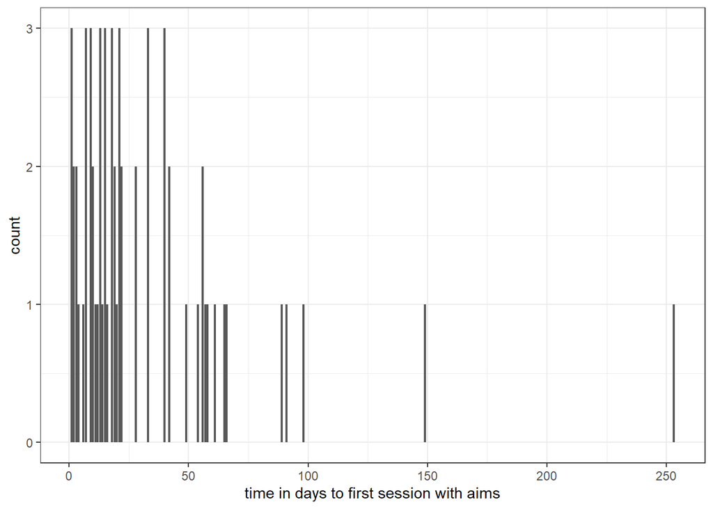

```r
ggplot(time_to_first_session,aes(x=time_in_d))+geom_bar()+xlab('time in days to first session with aims')
```

```r
df_date_first_session<-data.frame(df_firstaims_uniqueID$id,time_to_first_session$time_in_d,
                                  df_firstaims_uniqueID$sessno,df_firstaims_uniqueID$sdate_)

df_date_first_session$days_by_session<-round(df_date_first_session$time_to_first_session.time_in_d/
                                               df_date_first_session$df_firstaims_uniqueID.sessno,2)

names(df_date_first_session)<-c('id','days to first session','session number','date of first session','days / session')
df_date_first_session<-df_date_first_session[order(df_date_first_session$'days to first session'),]

df_date_first_session %>%
   kbl(caption = "first session with aims: date and time by IDs", row.names = FALSE) %>%
   kable_classic(full_width = T, html_font = "Cambria")
```

first session with aims: date and time by IDs

| id | days to first session | session number | date of first session | days / session |
| --- | --- | --- | --- | --- |
| 1.3 | 1 days | 2 | 2018-07-18 | 0.50 days |
| 2.16 | 1 days | 2 | 2019-06-06 | 0.50 days |
| 2.21 | 1 days | 2 | 2019-12-04 | 0.50 days |
| 2.29 | 2 days | 2 | 2020-03-12 | 1.00 days |
| 2.54 | 2 days | 2 | 2021-07-08 | 1.00 days |
| 2.19 | 3 days | 2 | 2019-08-02 | 1.50 days |
| 2.31 | 3 days | 2 | 2020-08-07 | 1.50 days |
| 2.11 | 4 days | 2 | 2019-02-18 | 2.00 days |
| 4.15 | 6 days | 2 | 2020-02-18 | 3.00 days |
| 1.11 | 7 days | 2 | 2018-11-19 | 3.50 days |
| 1.42 | 7 days | 3 | 2019-04-09 | 2.33 days |
| 1.74 | 7 days | 3 | 2020-05-14 | 2.33 days |
| 1.70 | 9 days | 4 | 2020-01-16 | 2.25 days |
| 2.35 | 9 days | 4 | 2021-02-24 | 2.25 days |
| 4.1 | 9 days | 3 | 2019-05-02 | 3.00 days |
| 1.5 | 10 days | 4 | 2018-08-17 | 2.50 days |
| 1.60 | 10 days | 4 | 2019-09-20 | 2.50 days |
| 2.33 | 11 days | 4 | 2020-08-07 | 2.75 days |
| 1.83 | 12 days | 4 | 2020-12-09 | 3.00 days |
| 1.31 | 13 days | 4 | 2018-11-27 | 3.25 days |
| 1.82 | 13 days | 2 | 2020-09-01 | 6.50 days |
| 3.106 | 13 days | 3 | 2021-06-21 | 4.33 days |
| 1.17 | 14 days | 3 | 2018-10-11 | 4.67 days |
| 1.50 | 15 days | 5 | 2019-08-09 | 3.00 days |
| 1.62 | 15 days | 4 | 2019-11-21 | 3.75 days |
| 2.2 | 15 days | 7 | 2018-12-11 | 2.14 days |
| 1.51 | 16 days | 6 | 2019-07-12 | 2.67 days |
| 1.97 | 18 days | 6 | 2021-03-02 | 3.00 days |
| 1.99 | 18 days | 5 | 2021-05-28 | 3.60 days |
| 4.9 | 18 days | 5 | 2019-10-04 | 3.60 days |
| 2.52 | 19 days | 5 | 2021-05-10 | 3.80 days |
| 4.25 | 19 days | 7 | 2021-01-27 | 2.71 days |
| 3.2 | 20 days | 7 | 2019-07-10 | 2.86 days |
| 2.46 | 21 days | 7 | 2021-02-19 | 3.00 days |
| 2.51 | 21 days | 5 | 2021-05-04 | 4.20 days |
| 3.31 | 21 days | 3 | 2020-02-24 | 7.00 days |
| 1.34 | 22 days | 3 | 2019-01-09 | 7.33 days |
| 3.4 | 22 days | 6 | 2019-10-30 | 3.67 days |
| 1.48 | 28 days | 5 | 2019-06-21 | 5.60 days |
| 1.93 | 28 days | 8 | 2021-02-03 | 3.50 days |
| 1.78 | 33 days | 9 | 2020-03-17 | 3.67 days |
| 1.87 | 33 days | 3 | 2021-01-05 | 11.00 days |
| 1.116 | 33 days | 7 | 2021-10-18 | 4.71 days |
| 1.81 | 40 days | 10 | 2020-07-28 | 4.00 days |
| 3.55 | 40 days | 7 | 2020-08-25 | 5.71 days |
| 4.2 | 40 days | 10 | 2019-06-12 | 4.00 days |
| 1.37 | 42 days | 12 | 2019-04-11 | 3.50 days |
| 4.23 | 42 days | 12 | 2020-11-16 | 3.50 days |
| 4.17 | 49 days | 13 | 2020-08-31 | 3.77 days |
| 3.98 | 54 days | 12 | 2021-04-14 | 4.50 days |
| 1.55 | 56 days | 9 | 2019-10-25 | 6.22 days |
| 1.113 | 56 days | 12 | 2021-11-01 | 4.67 days |
| 1.101 | 57 days | 11 | 2021-10-13 | 5.18 days |
| 1.54 | 58 days | 14 | 2019-12-11 | 4.14 days |
| 2.39 | 61 days | 10 | 2021-01-26 | 6.10 days |
| 4.19 | 65 days | 12 | 2021-01-13 | 5.42 days |
| 1.105 | 66 days | 5 | 2021-09-30 | 13.20 days |
| 1.94 | 89 days | 9 | 2021-04-14 | 9.89 days |
| 4.10 | 91 days | 19 | 2020-01-16 | 4.79 days |
| 1.76 | 98 days | 9 | 2020-05-26 | 10.89 days |
| 1.117 | 149 days | 28 | 2022-03-11 | 5.32 days |
| 2.4 | 253 days | 60 | 2019-08-20 | 4.22 days |

### 4.3.4 first session aims

the number of aims can be more than one per child

```r
#table overview
aims_table<-sort(table(droplevels(df_firstaims$aims)),decreasing = TRUE)
aims_table<-data.frame(aims_table)

aims_char_table<-sort(table(df_firstaims$aims_char),decreasing = TRUE)
aims_table<-data.frame(names(aims_char_table),aims_table)
names(aims_table)<-c('code','aim','occurances')

  aims_table %>%
  kbl(caption = "aims in the first session after introdcution") %>%
  kable_classic(full_width = F, html_font = "Cambria")
```

aims in the first session after introdcution

| code | aim | occurances |
| --- | --- | --- |
| 10.2.1 | eye contact | 48 |
| 9.4 | imitation | 27 |
| 9.3 | gaze following | 26 |
| 9.2 | attention control | 25 |
| 9.6 | action planing | 18 |
| 10.2.5 | expressive language extended | 16 |
| 10.2.2 | passive vocabulary | 11 |
| 9.5 | representation | 10 |
| 10.2.4 | expressive language (supported) | 7 |
| 10.3.1 | shared attention | 7 |
| 10.6.3 | problem solving | 7 |
| 10.3.5 | simple shared play | 6 |
| 10.3.6 | rule-based play | 6 |
| 9.7 | self awareness | 6 |
| 10.5.1 | classification | 4 |
| 10.5.4 | drawing | 4 |
| 10.6.6 | temporal orientation | 4 |
| 10.2.7 | making contact | 3 |
| 10.3.4 | non-interactive play | 3 |
| 10.4.1 | emotion recognition | 3 |
| 10.3.2 | exchange | 2 |
| 10.6.1 | daily routines | 2 |
| 10.2.3 | gesture | 1 |
| 10.2.6 | questions & answers | 1 |
| 10.3.3 | sharing | 1 |
| 10.3.7 | symbolic play | 1 |
| 10.4.3 | emotion regulation | 1 |
| 10.5.5 | quantitative understanding | 1 |
| 10.5.6 | theory of mind | 1 |
| 10.5.7 | common knowledge | 1 |
| B1 | aggression | 1 |
| B3 | stereotypic behavior | 1 |

```r
#aims by participant
table_aimspart<-by(df_firstaims$aims,df_firstaims$id,function(x){table(droplevels(x))})

table_aimspart<-sapply(table_aimspart,dimnames)
max_length<-max(sapply(table_aimspart,length))
table_aimspart<-lapply(table_aimspart,function(x){
  current_length<-length(x)
  new_vector<-rep(NA,max_length)
  new_vector[1:current_length]<-x
  return(new_vector)})

table_aimspart<-rbind.data.frame(table_aimspart)

table_aimspart<-data.frame(t(table_aimspart))
names(table_aimspart)<-paste('goal',1:length(names(table_aimspart)))
row.names(table_aimspart)<-substr(row.names(table_aimspart),2,nchar(row.names(table_aimspart)))

print('discussion point: Factor in the number of aims per participant?')
```

```
## [1] "discussion point: Factor in the number of aims per participant?"
```

```r
table_aimspart[order(table_aimspart[,1]),] %>%
  kbl(caption = "aims in the first session after introdcution by participant") %>%
  kable_classic(full_width = F, html_font = "Cambria")
```

aims in the first session after introdcution by participant

|  | goal 1 | goal 2 | goal 3 | goal 4 | goal 5 | goal 6 | goal 7 |
| --- | --- | --- | --- | --- | --- | --- | --- |
| 4.1 | aggression | stereotypic behavior | NA | NA | NA | NA | NA |
| 1.113 | attention control | gaze following | NA | NA | NA | NA | NA |
| 1.34 | attention control | NA | NA | NA | NA | NA | NA |
| 1.74 | attention control | gaze following | NA | NA | NA | NA | NA |
| 2.31 | attention control | gaze following | imitation | representation | self awareness | NA | NA |
| 1.54 | expressive language (supported) | attention control | imitation | NA | NA | NA | NA |
| 1.82 | expressive language (supported) | NA | NA | NA | NA | NA | NA |
| 1.3 | expressive language extended | attention control | NA | NA | NA | NA | NA |
| 1.99 | expressive language extended | NA | NA | NA | NA | NA | NA |
| 1.101 | eye contact | passive vocabulary | attention control | gaze following | imitation | action planing | NA |
| 1.105 | eye contact | attention control | action planing | NA | NA | NA | NA |
| 1.11 | eye contact | attention control | gaze following | imitation | representation | NA | NA |
| 1.116 | eye contact | shared attention | daily routines | action planing | NA | NA | NA |
| 1.117 | eye contact | non-interactive play | attention control | imitation | representation | action planing | NA |
| 1.31 | eye contact | sharing | gaze following | NA | NA | NA | NA |
| 1.37 | eye contact | shared attention | exchange | simple shared play | self awareness | NA | NA |
| 1.42 | eye contact | expressive language extended | problem solving | imitation | NA | NA | NA |
| 1.48 | eye contact | temporal orientation | NA | NA | NA | NA | NA |
| 1.50 | eye contact | passive vocabulary | gaze following | imitation | representation | action planing | NA |
| 1.51 | eye contact | attention control | gaze following | imitation | NA | NA | NA |
| 1.55 | eye contact | passive vocabulary | expressive language extended | problem solving | NA | NA | NA |
| 1.60 | eye contact | expressive language extended | making contact | simple shared play | problem solving | NA | NA |
| 1.62 | eye contact | passive vocabulary | expressive language extended | problem solving | action planing | NA | NA |
| 1.70 | eye contact | passive vocabulary | expressive language extended | problem solving | action planing | NA | NA |
| 1.76 | eye contact | attention control | action planing | NA | NA | NA | NA |
| 1.78 | eye contact | expressive language extended | questions & answers | shared attention | rule-based play | problem solving | gaze following |
| 1.81 | eye contact | expressive language extended | imitation | action planing | NA | NA | NA |
| 1.83 | eye contact | expressive language extended | shared attention | imitation | representation | NA | NA |
| 1.93 | eye contact | passive vocabulary | imitation | NA | NA | NA | NA |
| 1.94 | eye contact | temporal orientation | imitation | NA | NA | NA | NA |
| 1.97 | eye contact | attention control | gaze following | representation | NA | NA | NA |
| 2.16 | eye contact | passive vocabulary | expressive language (supported) | symbolic play | gaze following | imitation | self awareness |
| 2.19 | eye contact | expressive language (supported) | attention control | gaze following | NA | NA | NA |
| 2.2 | eye contact | making contact | rule-based play | daily routines | attention control | gaze following | NA |
| 2.21 | eye contact | attention control | gaze following | NA | NA | NA | NA |
| 2.29 | eye contact | attention control | imitation | representation | NA | NA | NA |
| 2.33 | eye contact | quantitative understanding | gaze following | action planing | self awareness | NA | NA |
| 2.35 | eye contact | passive vocabulary | expressive language (supported) | simple shared play | attention control | action planing | NA |
| 2.39 | eye contact | expressive language (supported) | emotion regulation | classification | imitation | action planing | NA |
| 2.4 | eye contact | making contact | rule-based play | emotion recognition | theory of mind | common knowledge | action planing |
| 2.51 | eye contact | passive vocabulary | classification | gaze following | imitation | action planing | self awareness |
| 2.52 | eye contact | expressive language (supported) | non-interactive play | simple shared play | gaze following | imitation | action planing |
| 2.54 | eye contact | attention control | NA | NA | NA | NA | NA |
| 3.106 | eye contact | shared attention | non-interactive play | imitation | representation | NA | NA |
| 3.2 | eye contact | rule-based play | classification | drawing | NA | NA | NA |
| 3.31 | eye contact | classification | attention control | gaze following | NA | NA | NA |
| 3.55 | eye contact | attention control | gaze following | representation | NA | NA | NA |
| 3.98 | eye contact | shared attention | exchange | emotion recognition | gaze following | imitation | NA |
| 4.10 | eye contact | expressive language extended | temporal orientation | NA | NA | NA | NA |
| 4.15 | eye contact | attention control | gaze following | representation | NA | NA | NA |
| 4.17 | eye contact | expressive language extended | shared attention | attention control | NA | NA | NA |
| 4.19 | eye contact | simple shared play | NA | NA | NA | NA | NA |
| 4.2 | eye contact | rule-based play | attention control | imitation | NA | NA | NA |
| 4.23 | eye contact | expressive language extended | problem solving | action planing | NA | NA | NA |
| 4.25 | eye contact | NA | NA | NA | NA | NA | NA |
| 4.9 | eye contact | NA | NA | NA | NA | NA | NA |
| 1.17 | gaze following | NA | NA | NA | NA | NA | NA |
| 1.87 | gaze following | NA | NA | NA | NA | NA | NA |
| 2.11 | gesture | expressive language extended | attention control | gaze following | imitation | self awareness | NA |
| 1.5 | passive vocabulary | expressive language extended | imitation | action planing | NA | NA | NA |
| 3.4 | passive vocabulary | rule-based play | emotion recognition | drawing | NA | NA | NA |
| 2.46 | simple shared play | gaze following | imitation | action planing | NA | NA | NA |

## 4.4 clustering first aims

- Gower Distance hierarchical clustering
- consider the first 7 goals of every participant at first session
- considers missing data (not all participants have equal number of aims)
- categorical data type

```r
# Cut into clusters (e.g., 3 clusters)
number_of_clusters<-5
print(paste('assumed number of clusters:',number_of_clusters))
```

```
## [1] "assumed number of clusters: 5"
```

```r
#translate
table_aimspart_factor<-lapply(table_aimspart,as.factor)
table_aimspart_factor<-data.frame(table_aimspart_factor[1],
                                  table_aimspart_factor[2],
                                  table_aimspart_factor[3],
                                  table_aimspart_factor[4],
                                  table_aimspart_factor[5],
                                  table_aimspart_factor[6],
                                  table_aimspart_factor[7])

rownames(table_aimspart_factor)<-row.names(table_aimspart)


# Compute Gower distance
gower_dist <- daisy(table_aimspart_factor, metric = "gower")
print('clustering metric - gower distance between pairwise comparisons (sum(1:64)):')
```

```
## [1] "clustering metric - gower distance between pairwise comparisons (sum(1:64)):"
```

```r
table(round(gower_dist,2))
```

```
##
##    0 0.17  0.2 0.25 0.33  0.4  0.5 0.57  0.6 0.67 0.71 0.75  0.8 0.83 0.86    1
##  123    1    1   19   47    9  216    2   24  249    1  344   93   34    7  721
```

```r
# Perform hierarchical clustering
hc <- hclust(gower_dist, method = "ward.D2")
clusters <- cutree(hc, k = number_of_clusters)


# Add cluster labels to your data
table_aimspart_factor$start_cluster <- clusters

print('5 clusters combine language aims better into distinct cluster')
```

```
## [1] "5 clusters combine language aims better into distinct cluster"
```

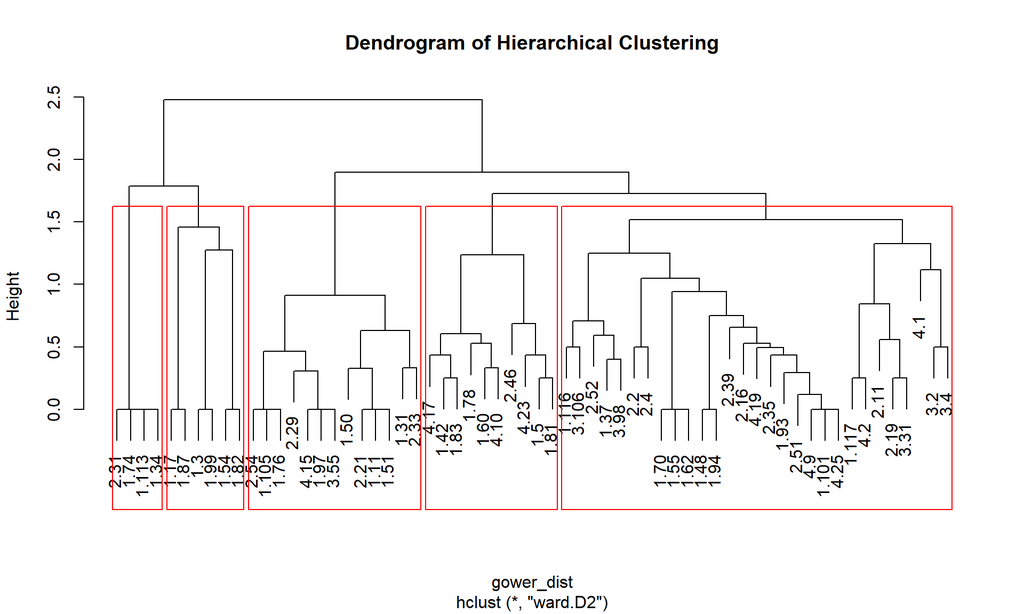

```r
# table_aimspart_factor[order(table_aimspart_factor[,8]),] %>%
#   kbl(caption = "aims in the first session and starting CLUSTERS after introduction by participant") %>%
#   kable_classic(full_width = F, html_font = "Cambria")


# visualize cluster
plot(hc, labels = rownames(table_aimspart_factor), main = "Dendrogram of Hierarchical Clustering")
rect.hclust(hc, k = number_of_clusters, border = "red")  # Draw boxes for clusters
```

```r
#add clusters to data
id<-row.names(table_aimspart_factor)
start_cluster<-table_aimspart_factor$start_cluster
df_cluster<-data.frame(id,start_cluster)
df_firstaims<-merge(df_firstaims,df_cluster,by='id')
df_firstaims$start_cluster<-as.factor(df_firstaims$start_cluster)

df_firstaims_uniqueID<-data.frame(df_firstaims[!duplicated(df_firstaims$id),])
df_firstaims_uniqueID<-df_firstaims_uniqueID[,names(df_firstaims_uniqueID) %in% c('id','start_cluster')]
df_trial<-merge(df_trial,df_firstaims_uniqueID,by='id')
```

### 4.4.1 describe clusters

- show 5 most common aims in different clusters
- label the clusters

```r
#show 5 most common aims in different clusters
cluster_aims<-by(table_aimspart_factor[,1:7],table_aimspart_factor$start_cluster,
   function(x){sort(table(droplevels(unlist(x))),decreasing=T)[1:5]})
cluster_aims<-lapply(cluster_aims,data.frame)
cluster_aims<-do.call(cbind,cluster_aims)
names(cluster_aims)<-rep(c('label','frequency'),number_of_clusters)

participants_in_clusters<-as.numeric(table(table_aimspart_factor$start_cluster))
header_label<-rep(2,number_of_clusters)
names(header_label)<-paste('cluster',1:number_of_clusters,'(n=',participants_in_clusters,')')

cluster_aims %>%
  kbl(caption = "5 most common aims in the first session by clusters") %>%
  kable_classic(full_width = F, html_font = "Cambria") %>%
  add_header_above(header_label)
```

5 most common aims in the first session by clusters

| cluster 1 (n= 29 ) label | cluster 1 (n= 29 ) frequency | cluster 2 (n= 13 ) label | cluster 2 (n= 13 ) frequency | cluster 3 (n= 4 ) label | cluster 3 (n= 4 ) frequency | cluster 4 (n= 6 ) label | cluster 4 (n= 6 ) frequency | cluster 5 (n= 10 ) label | cluster 5 (n= 10 ) frequency |
| --- | --- | --- | --- | --- | --- | --- | --- | --- | --- |
| eye contact | 26 | eye contact | 13 | attention control | 4 | attention control | 2 | expressive language extended | 9 |
| imitation | 12 | attention control | 10 | gaze following | 3 | expressive language (supported) | 2 | eye contact | 8 |
| action planing | 10 | gaze following | 9 | imitation | 1 | expressive language extended | 2 | imitation | 5 |
| gaze following | 9 | representation | 6 | representation | 1 | gaze following | 2 | action planing | 4 |
| passive vocabulary | 9 | action planing | 4 | self awareness | 1 | imitation | 1 | problem solving | 4 |

### 4.4.2 moderating clusters

- non-parametric Fisher’s exact Test (categorical outcome = cluster, categorical predictor)
- no moderator had an influence

```r
#select only one row per participant
df_firstaims_uniqueID<-df_firstaims[!duplicated(df_firstaims$id),]
table(df_firstaims_uniqueID$start_cluster)
```

```
##
##  1  2  3  4  5
## 29 13  4  6 10
```

```r
#nonparametric testing - categorical variables
print('gender:')
```

```
## [1] "gender:"
```

```r
with(df_firstaims_uniqueID,table(start_cluster, gender))
```

```
##              gender
## start_cluster  1  2
##             1 25  4
##             2 10  3
##             3  3  1
##             4  4  2
##             5  8  2
```

```r
with(df_firstaims_uniqueID,fisher.test(table(start_cluster, gender)))
```

```
##
##  Fisher's Exact Test for Count Data
##
## data:  table(start_cluster, gender)
## p-value = 0.7036
## alternative hypothesis: two.sided
```

```r
print('migration status:')
```

```
## [1] "migration status:"
```

```r
with(df_firstaims_uniqueID,table(start_cluster, migration))
```

```
##              migration
## start_cluster  0  1
##             1  9 20
##             2  5  8
##             3  1  3
##             4  2  4
##             5  5  5
```

```r
with(df_firstaims_uniqueID,fisher.test(table(start_cluster, migration)))
```

```
##
##  Fisher's Exact Test for Count Data
##
## data:  table(start_cluster, migration)
## p-value = 0.8736
## alternative hypothesis: two.sided
```

```r
print('parental education:')
```

```
## [1] "parental education:"
```

```r
with(df_firstaims_uniqueID,table(start_cluster, maxschool_t1))
```

```
##              maxschool_t1
## start_cluster  1  2  3  4  5
##             1  1 10  0 16  2
##             2  0  7  0  5  1
##             3  0  2  0  2  0
##             4  0  3  1  2  0
##             5  0  3  0  6  1
```

```r
with(df_firstaims_uniqueID,fisher.test(table(start_cluster, maxschool_t1)))
```

```
##
##  Fisher's Exact Test for Count Data
##
## data:  table(start_cluster, maxschool_t1)
## p-value = 0.8139
## alternative hypothesis: two.sided
```

```r
print('lockdown status:')
```

```
## [1] "lockdown status:"
```

```r
with(df_firstaims_uniqueID,table(start_cluster, after_lockdown))
```

```
##              after_lockdown
## start_cluster FALSE TRUE
##             1    16   13
##             2     7    6
##             3     1    3
##             4     3    3
##             5     5    5
```

```r
with(df_firstaims_uniqueID,fisher.test(table(start_cluster, after_lockdown)))
```

```
##
##  Fisher's Exact Test for Count Data
##
## data:  table(start_cluster, after_lockdown)
## p-value = 0.9017
## alternative hypothesis: two.sided
```

```r
#--> significant influence of lockdown - sessions after lockdown take longer to reach aims
with(df_firstaims_uniqueID,by(sessno,after_lockdown,psych::describe))
```

```
## after_lockdown: FALSE
##    vars  n mean    sd median trimmed  mad min max range skew kurtosis   se
## X1    1 32 7.03 10.45      4    4.85 2.97   2  60    58 4.09    17.74 1.85
## ------------------------------------------------------------
## after_lockdown: TRUE
##    vars  n mean   sd median trimmed  mad min max range skew kurtosis   se
## X1    1 30 7.57 5.18      7       7 4.45   2  28    26 1.95     5.43 0.95
```

```r
#nonparametric testing - continous variables
print('age:')
```

```
## [1] "age:"
```

```r
with(df_firstaims_uniqueID, kruskal.test(agedemo ~ start_cluster))
```

```
##
##  Kruskal-Wallis rank sum test
##
## data:  agedemo by start_cluster
## Kruskal-Wallis chi-squared = 3.9333, df = 4, p-value = 0.4151
```

```r
print('IQ:')
```

```
## [1] "IQ:"
```

```r
with(df_firstaims_uniqueID, kruskal.test(full_iq ~ start_cluster))
```

```
##
##  Kruskal-Wallis rank sum test
##
## data:  full_iq by start_cluster
## Kruskal-Wallis chi-squared = 6.5759, df = 4, p-value = 0.1601
```

```r
print('SES:')
```

```
## [1] "SES:"
```

```r
with(df_firstaims_uniqueID, kruskal.test(ses_edumean_t1 ~ start_cluster))
```

```
##
##  Kruskal-Wallis rank sum test
##
## data:  ses_edumean_t1 by start_cluster
## Kruskal-Wallis chi-squared = 2.2109, df = 4, p-value = 0.697
```

## 4.5 therapy aims - expert level

- expert level defines a type of mastery of a specific aim
- last number defines expert level (1,2,3)
- can be utilized as outcome measure of training

```r
expert_level<-substr(df_trial$aimno,5,8)
expert_level<-ifelse(nchar(expert_level)==4,substr(expert_level,4,4),expert_level)
expert_level<-ifelse(nchar(expert_level)==0,NA,expert_level)

expert_level<-as.factor(expert_level)
levels(expert_level)<-c('beginner','intermediate','expert')

df_trial$expert_level<-expert_level

with(df_trial,table(dev_area,expert_level))
```

```
##                                      expert_level
## dev_area                              beginner intermediate expert
##   communication & speech (10.2)           3461         1029    953
##   interaction & play (10.3)               1180          825    533
##   emotion (10.4)                           197          126    105
##   cognitive ability (10.5)                 219          369    256
##   daily living skills (10.6)               859          182    122
##   basic abilities (9)                     2733         1651    794
##   introduction (A)                           0            0      0
##   reduction of unwanted behaviors (B)        0            0      0
```

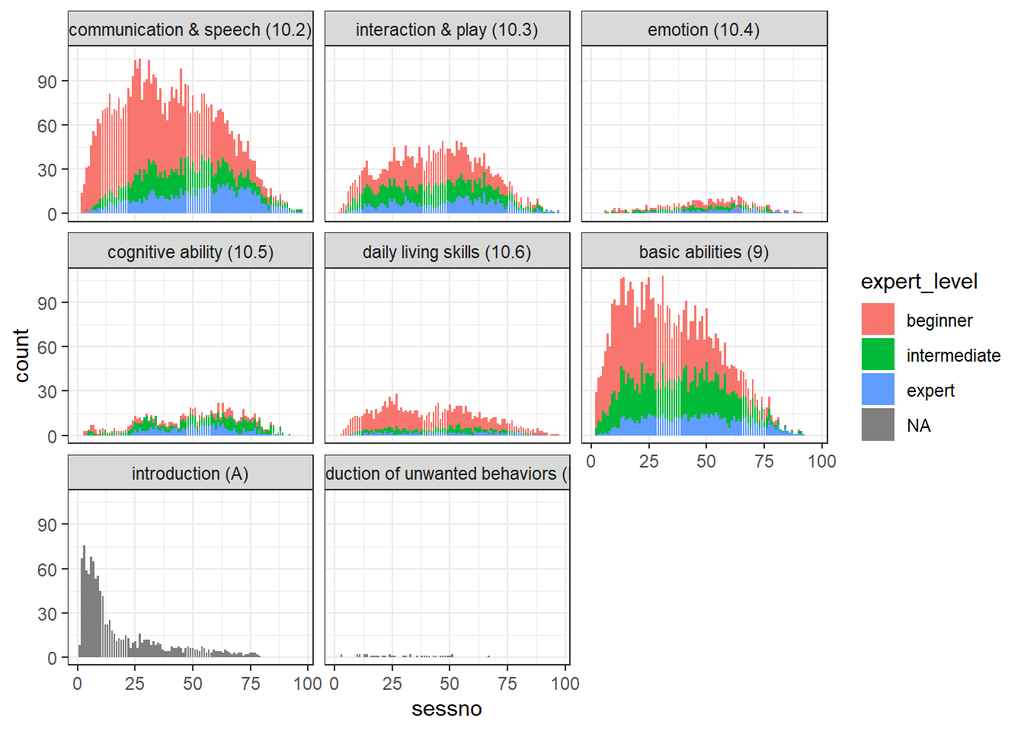

```r
ggplot(df_trial,aes(x=sessno,fill=expert_level))+geom_bar()+facet_wrap(~dev_area)
```

# 5 chains of aims

- identifiy chains of aims
- at least 2 consecutive sessions with one aim should be later considered

## 5.1 chain functions

```r
#function to extract outcome data for chains of a single aim within one participant
#outocme data includes: achieve, help
fun_chain_metrics<-function(single_chain){
#chain static info
single_chain_outcome<-single_chain[1,names(single_chain) %in% c('id','centno','scrnno','aims','aims_char',
                                                                'dev_area','dev_area_char','start_cluster',
                                                                'gender','agedemo','develop_age','verbal_iq',
                                                                'nonverbal_iq','full_iq','test_age',
                                                                'migration','maxschool_t1','ses_edumean_t1',
                                                                'after_lockdown')]


#chain characterization
chain_length<-nrow(single_chain)
chain_first_session<-min(single_chain$sessno)
chain_last_session<-max(single_chain$sessno)
chain_first_date<-min(single_chain$sdate_)
chain_last_date<-max(single_chain$sdate_)
chain_after_lockdown_percentage<-mean(single_chain$after_lockdown)
chain_behave_mean<-mean(single_chain$behave)
#chain outcome metrics
chain_achieve_mean<-mean(single_chain$achieve)
chain_achieve_first<-single_chain$achieve[single_chain$sessno==chain_first_session]
chain_achieve_last<-single_chain$achieve[single_chain$sessno==chain_last_session]
chain_achieve_0<-sum(single_chain$achieve==0)
chain_achieve_1<-sum(single_chain$achieve==1)
chain_achieve_2<-sum(single_chain$achieve==2)
chain_help_mean<-mean(single_chain$help)
chain_help_first<-single_chain$help[single_chain$sessno==chain_first_session]
chain_help_last<-single_chain$help[single_chain$sessno==chain_last_session]
chain_help_0<-sum(single_chain$help==0)
chain_help_1<-sum(single_chain$help==1)
chain_help_2<-sum(single_chain$help==2)
chain_expertlevel_beginner<-sum(single_chain$expert_level=='beginner')
chain_expertlevel_intermediate<-sum(single_chain$expert_level=='intermediate')
chain_expertlevel_expert<-sum(single_chain$expert_level=='expert')

single_chain_variables<-data.frame(
  #chain characterization
  chain_length,
  chain_first_session,
  chain_last_session,
  chain_first_date,
  chain_last_date,
  chain_after_lockdown_percentage,
  chain_behave_mean,
  #chain outcome metrics
  chain_achieve_mean,
  chain_achieve_first,
  chain_achieve_last,
  chain_achieve_0,
  chain_achieve_1,
  chain_achieve_2,
  chain_help_mean,
  chain_help_first,
  chain_help_last,
  chain_help_0,
  chain_help_1,
  chain_help_2,
  chain_expertlevel_beginner,
  chain_expertlevel_intermediate,
  chain_expertlevel_expert
  )

single_chain_outcome<-data.frame(single_chain_outcome,single_chain_variables)
return(single_chain_outcome)

}

#function that loops fun_chain_metrics across aims by participant
fun_chain_loop_ids_aims<-function(single_participant){

#testing:
#single_participant<-list_trial[[22]]

#identify aims
all_aims<-names(table(droplevels(single_participant$aims)))

#identifies chains for participant - loops across all aims of a participant
single_participant_chains<-list()
for(i in 1:length(all_aims)){
single_participant_single_aim<-single_participant[single_participant$aims==all_aims[i],]
# Identify breaks
group_id <- cumsum(c(TRUE, diff(single_participant_single_aim$sessno) != 1))
# Split into list of chains
chains <- split(single_participant_single_aim, group_id)
#apply fun_chain_metrics to each list element
chains_of_single_aim<-lapply(chains,fun_chain_metrics)
#return to data.frame
chains_of_single_aim<-rbindlist(chains_of_single_aim)
#retrieve number of chains for single aim
chains_of_single_aim$aim_chain_nr<-1:nrow(chains_of_single_aim)
single_participant_chains[[i]]<-chains_of_single_aim
}

names(single_participant_chains)<-all_aims #names list of chains by aims
single_participant_chains<-rbindlist(single_participant_chains) #turn list of chains to data.frame
return(single_participant_chains)

}
```

## 5.2 chain data extraction

- splits data by participants
- splits single participant by aims
- create chains for every participant (for loop)
- create mastery variable based on expert level

```r
#split by participant
list_trial<-split(df_trial,df_trial$id)
list_trial<-lapply(list_trial,function(x){x[order(x$sessno),]})

# applies fucntions above in loop (partiicpants) of loops (aims per participant)
list_chains<-pblapply(list_trial,fun_chain_loop_ids_aims)
df_chains<-rbindlist(list_chains)

#create additional variable
df_chains$chain_mastery_mean<-with(df_chains,
             ((chain_expertlevel_beginner*0)+(chain_expertlevel_intermediate*1)+(chain_expertlevel_expert*2))/
               (chain_expertlevel_beginner+chain_expertlevel_intermediate+chain_expertlevel_expert))
```

## 5.3 chain description

```r
table(df_chains$chain_length) %>%
  kbl(caption = "total chain length") %>%
  kable_classic(full_width = F, html_font = "Cambria")
```

total chain length

| Var1 | Freq |
| --- | --- |
| 1 | 2634 |
| 2 | 1439 |
| 3 | 759 |
| 4 | 505 |
| 5 | 315 |
| 6 | 174 |
| 7 | 137 |
| 8 | 112 |
| 9 | 85 |
| 10 | 30 |
| 11 | 35 |
| 12 | 24 |
| 13 | 9 |
| 14 | 11 |
| 15 | 22 |
| 16 | 5 |
| 21 | 1 |

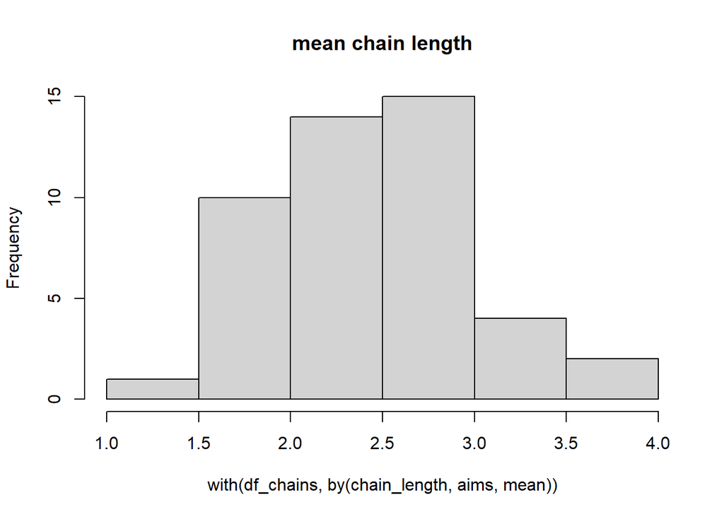

```r
hist(with(df_chains,by(chain_length,aims,mean)),main = 'mean chain length')
```

```r
table_chainlength<-data.frame(with(df_chains,by(chain_length,aims,function(x){round(mean(x),2)})))
chain_occurances<-as.numeric(with(df_chains,by(chain_length,aims,length)))
table_chainlength<-data.frame(table_chainlength,chain_occurances)

table_chainlength<-table_chainlength[order(table_chainlength[,1],decreasing = T),]
names(table_chainlength)<-c('mean chain length','chain occurances')

table_chainlength %>%
  kbl(caption = "mean chain length by aim") %>%
  kable_classic(full_width = F, html_font = "Cambria")
```

mean chain length by aim

|  | mean chain length | chain occurances |
| --- | --- | --- |
| situational control | 3.68 | 128 |
| toilet training | 3.67 | 6 |
| action planing | 3.32 | 307 |
| building therapeutic alliance | 3.28 | 68 |
| representation | 3.09 | 100 |
| expressive language extended | 3.01 | 439 |
| eye contact | 2.97 | 732 |
| separation from caregiver | 2.97 | 62 |
| problem solving | 2.94 | 249 |
| expressive language (supported) | 2.92 | 221 |
| simple shared play | 2.88 | 173 |
| making contact | 2.76 | 49 |
| spatial awareness | 2.75 | 4 |
| passive vocabulary | 2.73 | 324 |
| testing reinforcement | 2.72 | 78 |
| questions & answers | 2.66 | 70 |
| attention control | 2.64 | 414 |
| gaze following | 2.61 | 340 |
| shared attention | 2.58 | 224 |
| daily routines | 2.53 | 47 |
| quantitative understanding | 2.51 | 53 |
| characteristics/opposites | 2.48 | 31 |
| imitation | 2.46 | 518 |
| temporal orientation | 2.42 | 86 |
| awareness of danger | 2.32 | 31 |
| self awareness | 2.30 | 258 |
| classification | 2.27 | 177 |
| sharing | 2.25 | 69 |
| rule-based play | 2.25 | 217 |
| alternatives | 2.20 | 5 |
| common knowledge | 2.15 | 13 |
| non-interactive play | 2.09 | 122 |
| emotion expression | 2.04 | 27 |
| emotion regulation | 2.02 | 47 |
| emotion recognition | 2.01 | 138 |
| gesture | 2.00 | 49 |
| symbolic play | 2.00 | 85 |
| aggression | 2.00 | 2 |
| avoidance | 2.00 | 5 |
| exchange | 1.99 | 154 |
| theory of mind | 1.88 | 50 |
| anxiety | 1.86 | 7 |
| drawing | 1.84 | 55 |
| memory | 1.80 | 5 |
| role play | 1.54 | 57 |
| stereotypic behavior | 1.00 | 1 |

## 5.4 chain visualization

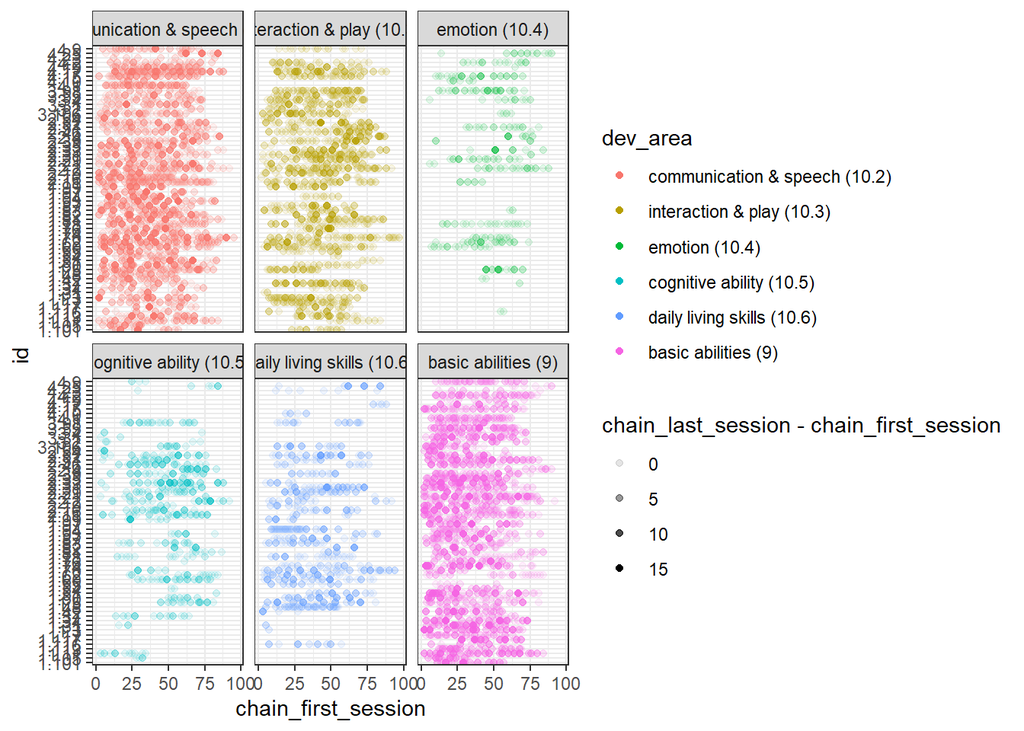

```r
ggplot(df_chains[!df_chains$dev_area_char %in% c('A','B')],
       aes(chain_first_session,id,alpha=chain_last_session-chain_first_session,color=dev_area))+geom_point()+facet_wrap(~dev_area)
```

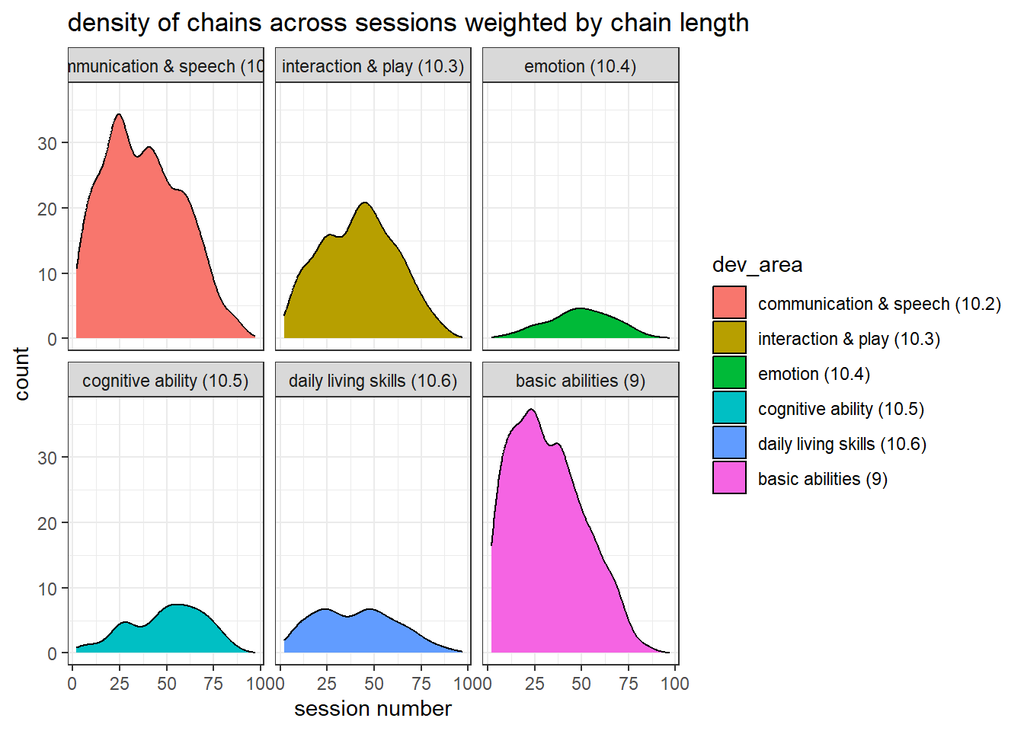

```r
ggplot(df_chains[!df_chains$dev_area_char %in% c('A','B')],
       aes(chain_first_session,weight=chain_last_session-chain_first_session,fill=dev_area))+
  geom_density(aes(y = after_stat(count)), adjust = 1)+ #weighted by occurances
  labs(x='session number',title = 'density of chains across sessions weighted by chain length')+
  facet_wrap(~dev_area)
```

## 5.5 chain analysis

```r
require(lme4)
require(lmerTest)
#describe outcome variables
psych::describe(df_chains$chain_length)
```

```
##    vars    n mean   sd median trimmed  mad min max range skew kurtosis   se
## X1    1 6297 2.66 2.35      2    2.15 1.48   1  21    20 2.28     6.54 0.03
```

```r
psych::describe(df_chains$chain_help_mean)
```

```
##    vars    n mean   sd median trimmed  mad min max range  skew kurtosis   se
## X1    1 6015 1.13 0.53      1    1.15 0.21   0   2     2 -0.07    -0.08 0.01
```

```r
psych::describe(df_chains$chain_achieve_mean)
```

```
##    vars    n mean   sd median trimmed mad min max range  skew kurtosis   se
## X1    1 6015  1.1 0.53      1    1.12   0   0   2     2 -0.07     0.04 0.01
```

```r
psych::describe(df_chains$chain_mastery_mean)
```

```
##    vars    n mean   sd median trimmed  mad min max range skew kurtosis   se
## X1    1 5941 0.67 0.76    0.5    0.59 0.74   0   2     2 0.67    -0.99 0.01
```

```r
#prepare data
lmm_data<-df_chains[df_chains$chain_after_lockdown_percentage %in% c(0,1),]

# function to plot model as APA table
fun_table_lmm<-function(lmm,caption){

lmm_summary<-data.frame(round(summary(lmm)$coefficients,3))
names(lmm_summary)<-c('estimate','SE','df','t-value','p-value')
variable<-c('intercept','chain length','full IQ','gender','age','after lockdown')
lmm_summary<-data.frame(variable,lmm_summary)

lmm_summary %>%
  kbl(caption = caption,row.names = F) %>%
  kable_classic(full_width = F, html_font = "Cambria")

}

lmm<-lmer(scale(chain_help_mean)~scale(chain_length)+scale(full_iq)+gender+scale(agedemo)+
            as.factor(chain_after_lockdown_percentage)+(1|id),data=lmm_data)
fun_table_lmm(lmm,caption="help outcome: effect of chain length")
```

help outcome: effect of chain length

| variable | estimate | SE | df | t.value | p.value |
| --- | --- | --- | --- | --- | --- |
| intercept | -0.186 | 0.186 | 55.873 | -0.998 | 0.323 |
| chain length | 0.033 | 0.013 | 5490.968 | 2.508 | 0.012 |
| full IQ | 0.143 | 0.061 | 51.335 | 2.348 | 0.023 |
| gender | 0.020 | 0.149 | 52.365 | 0.134 | 0.894 |
| age | -0.040 | 0.059 | 50.936 | -0.678 | 0.501 |
| after lockdown | 0.153 | 0.052 | 1546.838 | 2.931 | 0.003 |

```r
lmm<-lmer(scale(chain_achieve_mean)~scale(chain_length)+scale(full_iq)+gender+scale(agedemo)+
            as.factor(chain_after_lockdown_percentage)+(1|id),data=lmm_data)
fun_table_lmm(lmm,caption="achieve outcome: effect of chain length")
```

achieve outcome: effect of chain length

| variable | estimate | SE | df | t.value | p.value |
| --- | --- | --- | --- | --- | --- |
| intercept | -0.219 | 0.218 | 54.682 | -1.002 | 0.321 |
| chain length | 0.043 | 0.013 | 5479.565 | 3.452 | 0.001 |
| full IQ | 0.330 | 0.072 | 51.429 | 4.600 | 0.000 |
| gender | 0.061 | 0.176 | 52.114 | 0.345 | 0.732 |
| age | -0.005 | 0.070 | 51.141 | -0.065 | 0.948 |
| after lockdown | 0.153 | 0.051 | 2551.468 | 2.993 | 0.003 |

```r
lmm<-lmer(scale(chain_mastery_mean)~scale(chain_length)+scale(full_iq)+gender+scale(agedemo)+
            as.factor(chain_after_lockdown_percentage)+(1|id),data=lmm_data)
fun_table_lmm(lmm,caption="mastery outcome: effect of chain length")
```

mastery outcome: effect of chain length

| variable | estimate | SE | df | t.value | p.value |
| --- | --- | --- | --- | --- | --- |
| intercept | -0.339 | 0.137 | 54.263 | -2.481 | 0.016 |
| chain length | -0.037 | 0.013 | 5429.971 | -2.877 | 0.004 |
| full IQ | 0.308 | 0.044 | 47.922 | 7.023 | 0.000 |
| gender | 0.069 | 0.108 | 49.628 | 0.634 | 0.529 |
| age | 0.080 | 0.043 | 47.371 | 1.893 | 0.064 |
| after lockdown | 0.288 | 0.048 | 632.264 | 5.988 | 0.000 |

- clustern based on clusters and quality of clusters
- Prüfung der weiteren Angaben der Therapieziel im Verlauf der Therapie -> Stabilität bzw. Wechsel in andere Kategorie.